# Estimating $R_0$ and other parameters for the 2019-nCov epidemic

May 28, 2020

### Basic reproduction number $R_0$

#### Overview

$R_0$, the *basic reproduction number*, is defined as the average number of secondary cases expected to arise from a single infected individual in a wholly susceptible population. $R_{eff}$, the *effective reproduction number*, refers to the expected number of secondary cases to arise from an arbitrary case at any point in time. $R_{eff}$ is expected to change over the course of an outbreak. Containment will occur when $R_{eff}<1$.

Estimating $R_0$ and $R_{eff}$ in this outbreak are challenging because: 1. There is little information from the first few infection generations 2. The distribution of incubation period and time from presentation of symptoms to hospitalization are not exponentially distributed 3. Interventions and policies intended to curtail the outbreak have affected the unfolding process and are therefore reflected in the case notification data.

#### Takeoff estimators

We have considered ‘’takeoff’’ estimators (e.g. Wearing et al. https://journals.plos.org/plosmedicine/article?id=10.1371/journal.pmed.0020174). Wearing et al. show that dynamics of an epidemic in the early phases are related to $R_0$. A regression line through plot of case notifications over time, from the start of the outbreak on 1 December 2020 (neglecting the first couple points), clearly does not go through the origin, suggesting that the epidemic was already in its exponential phase by Day 47 (Jan 16). If $\gamma$ were constant during this period after Day 47 (which it’s probably not, due to increasing case isolation), the number of cases would be expected to grow according to the proportionality

$$\begin{equation}
log(X_t) \propto (R_0-1)\gamma t.
\end{equation}$$

Although $\gamma$ is changing, we can nevertheless use this method to provide upper and lower bounds on $R_{eff}$ by looking at the plausible range of $\gamma$ (i.e., it’s minimum at $\gamma \approx 1/7$ and its maximum at $\gamma \approx 1$.

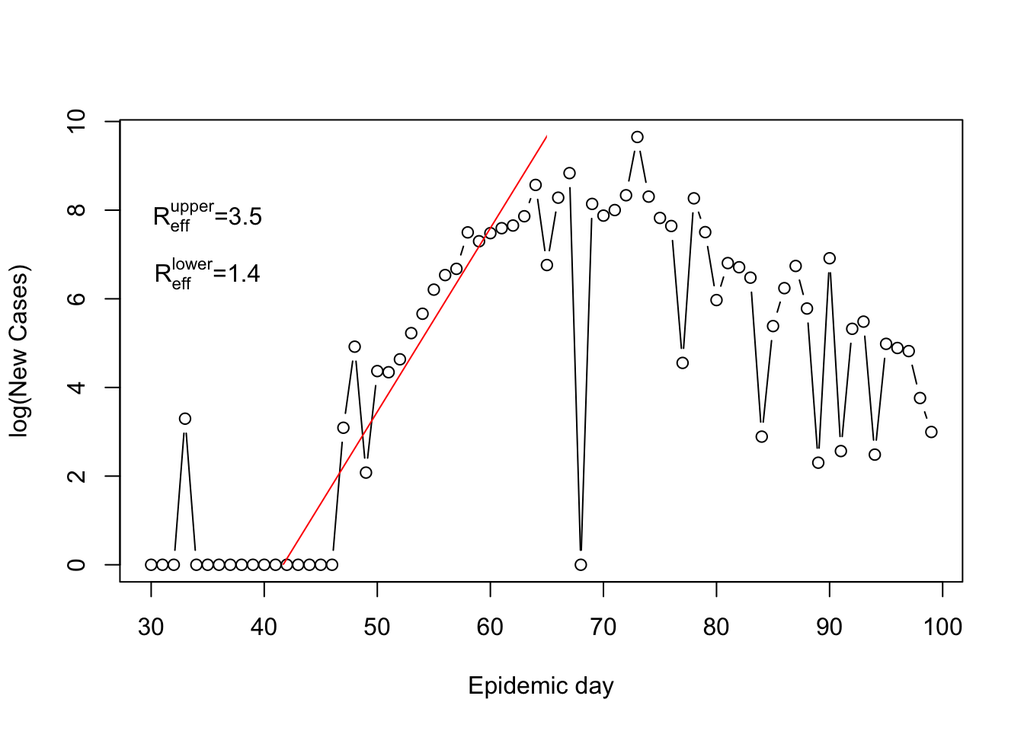

Upper and lower bounds on $R_0$ for China using Wearing et al. method

$$\begin{equation}
R_0 = \lambda_2(\lambda_2/(\sigma m)+1)^m/(\gamma (1-(\lambda_2/(\gamma n)+1)^{-n})),
\end{equation}$$

where $\lambda_2$ is the slope of the takeoff at the *beginning* of the epidemic, $1/\sigma$ is the average latent period, $1/\gamma$ is the average infectious period and $m$ and $n$ are the parameters of Erlang distributions for the interval (Wearing and Rohani).

Inserting into the formula yields the estimate: $\hat R_0 \approx 2.28$.

### Case detection rate ($q$)

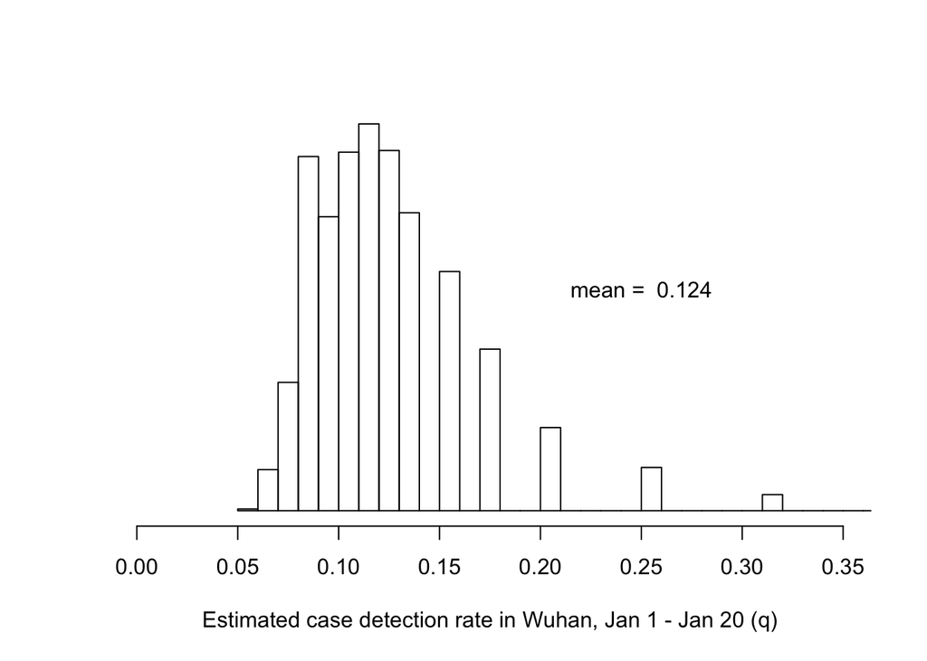

### Incubation period ($1/\sigma$)

Travelers who acquired the infection in a location where transmission was occurring and developed symptoms at a later time provide an opportunity to estimate the incubation period. Using data from the [Be Outbreak Prepared (BOP)](https://github.com/beoutbreakprepared) linelist, we estimate the incubation period to have a mean of 5.25 days. By maximum likelihood, we have determined that $k=2$ is the most likely shape parameter for an Erlang distributed onset to isolation interval.

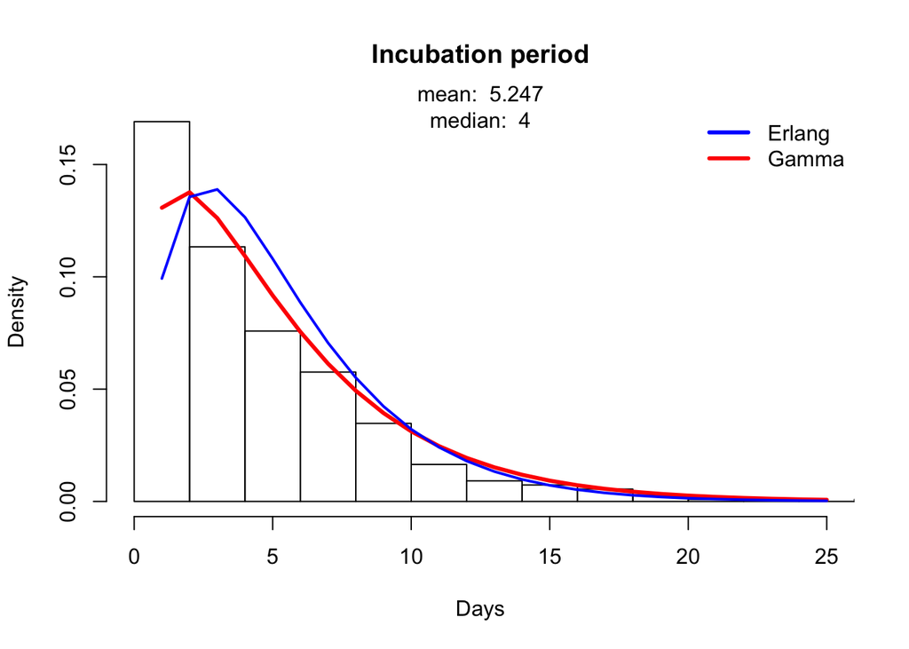

Estimated and observed distribution of incubation times.

### Lag between symptom onset and isolation

A key determinant of transmission is the lag between the onset of symptoms and isolation. The inverse of this quantity is the *isolation rate*. By maximum likelihood, we have determined that $k=2$ is the most likely shape parameter for an Erlang distributed onset to hospitalization interval. We determined that $k=3$ is the most likley shape parameter for an Erlang distributed onset to confirmation interval.

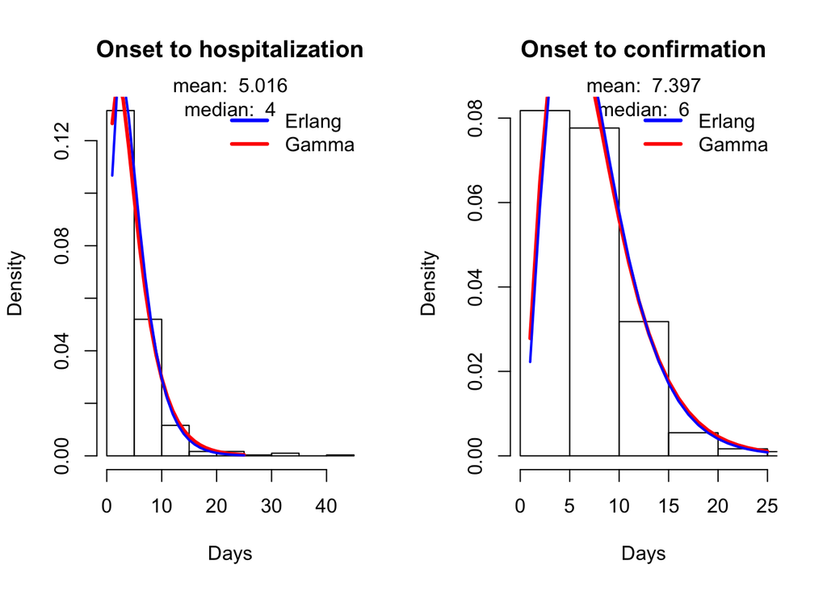

### Case fatality rate (CFR)

Here we estimate case fatality rate using the number of reported deaths ($D$) and cases ($C$) in each province. The grand mean is 5.5% (confidence interval: [0.054, 0.057]).

The standard of care for COVID has evolved over the course of the epidemic and the case fatality rate outside Hubei is considerably lower than in Hubei. Hubei has the highest estimated CFR with 6.6% (CI: [6.4, 6.8]). We estimate the case fatality rate outside of Hubei to be 0.9% (CI: [.7%, 1%]).

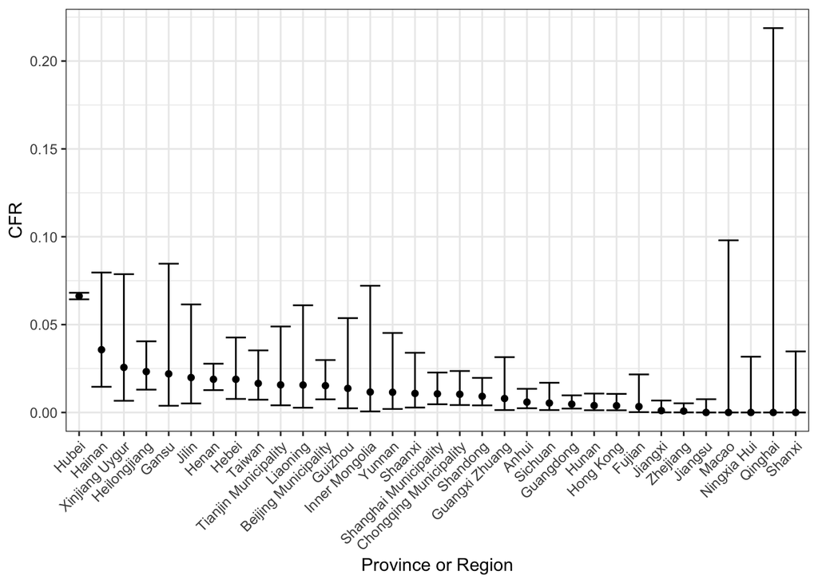

Estimated case fatality rates by province or region in China.

### Transmissibility ($\beta$)

Transmissibility ($\beta$) is defined in the usual way by rearranging the equation $R_0 = \frac{\beta}{\gamma}$ to give $\beta = R_0 \times \gamma$. Taking our estimate from the early stages of the outbreak and fixed infectious period ($\gamma = 1/7$) we conclude that $\beta$ ranges from $\beta = R_0 \times \gamma = 1.4/7 = 0.2$ to $\beta = R_0 \times \gamma = 3.5/7 = 0.5$. For comparison, if we use the Imperial College estimate of $R_0=2.6$, we obtain $\beta = 2.6/ 7 = 0.371$.

### Data

Key resources used for this investigation include:

1. A [record of case reports at the province level in China](https://raw.githubusercontent.com/CEIDatUGA/COVID-19-DATA/master/china/China_casedata/dxy_data/prefecture_master.csv) maintained by the CEID at the University of Georgia
2. A global linelist maintained by [Be Outbreak Prepared (BOP)](https://github.com/beoutbreakprepared) This dataset was preceded by the “Moritz Kraemer” linelist and has since been published in the Lancet

Note: There are known discrepancies among these data sets.